# Example Report

## Exploring Body Mass Differences

Exploratory data analysis is not limited to relationships between numerical variables. Relationships between categorical and numerical variables can also provide valuable insights. The following example examines differences in body mass across sex categories.

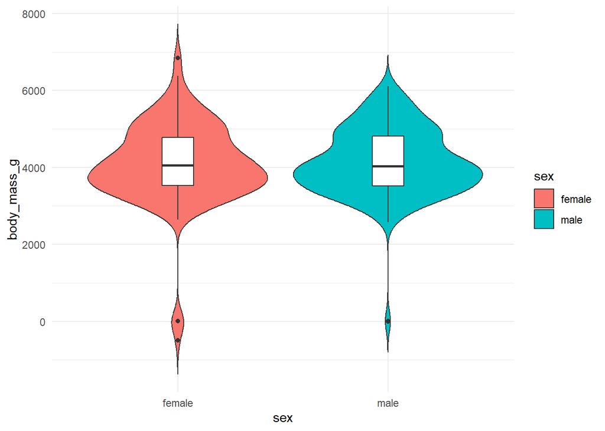

```r
data |>
  filter(!is.na(sex)) |>
  ggplot(
    aes(
      x = sex,
      y = body_mass_g,
      fill = sex
    )
  ) +
  geom_violin(trim = FALSE) +
  geom_boxplot(
    width = 0.15,
    fill = "white"
  ) +
  theme_minimal()
```

```r
data |>
  filter(!is.na(sex)) |>
  group_by(sex) |>
  summarise(
    Mean_Body_Mass = mean(
      body_mass_g,
      na.rm = TRUE
    ),
    SD = sd(
      body_mass_g,
      na.rm = TRUE
    )
  )
```

| sex | Mean_Body_Mass | SD |
| --- | --- | --- |
| female | 4083.130 | 1089.4874 |
| male | 4142.375 | 890.8178 |

## Summary of EDA

> The exploratory analysis provided a better understanding of the dataset structure and quality. Several data quality issues were identified, including missing values, inconsistent category labels, duplicate records, and unusual observations. The analysis also revealed potential relationships between variables that may be useful for predictive modelling. These findings support the data preparation decisions described in the previous section and provide a foundation for model development.

# 5. Modeling

## Data Preparation Strategy

The exploratory analysis revealed several data quality issues, including missing values, duplicate records, inconsistent categorical labels, and extreme observations. Appropriate preprocessing steps were therefore applied to improve data consistency and prepare the dataset for machine learning models.

```r
library(tidyverse)
library(tidymodels)
```

## Selected Features

The target variable for this project is `species`.

The following variables were retained as potential predictors:

- bill_length_mm
- bill_depth_mm
- flipper_length_mm
- body_mass_g
- island
- sex
- year

The `notes` variable was excluded from further analysis due to its large number of missing values and limited analytical relevance.

```r
model_data <- data |>
  select(
    species,
    bill_length_mm,
    bill_depth_mm,
    flipper_length_mm,
    body_mass_g,
    island,
    sex,
    year
  )
```

## Data Cleaning

Duplicate observations were removed and categorical variables were standardized to ensure consistent representation across the dataset. Obvious data quality issues and implausible observations identified during exploratory analysis were addressed prior to modelling.

```r
model_data <- model_data |>
  distinct() |>
  mutate(
    species = str_to_title(species),
    island = str_to_title(island),
    sex = str_to_lower(sex),
    sex = recode(
      sex,
      "m" = "male",
      "f" = "female"
    ),
    species = recode(
      species,
      "Gent00" = "Gentoo"
    )
  ) |>
  filter(
    bill_length_mm < 100 | is.na(bill_length_mm),
    flipper_length_mm < 400 | is.na(flipper_length_mm),
    body_mass_g < 10000 | is.na(body_mass_g),
    year < 2100 | is.na(year)
  )
```

## Handling Missing Values

Missing values remained in selected variables after the cleaning process. These observations were retained and handled through model-specific preprocessing techniques during model training.

Three possible strategies may be considered for the `sex` variable:

- removing observations with missing values,
- replacing missing values with a new category,
- imputing missing values during model training.

In this report, the third approach is preferred because it keeps more observations in the dataset and allows preprocessing to be included directly in the modelling workflow.

### Option 1: Removing Records with Missing `sex`

```r
model_data_option_1 <- model_data |>
  drop_na(sex)
```

This approach is simple, but it reduces the size of the dataset. It may be acceptable when the number of missing observations is small, but it can also remove potentially useful information.

### Option 2: Creating an `unknown` Category

```r
model_data_option_2 <- model_data |>
  mutate(
    sex = replace_na(sex, "unknown")
  )
```

This approach preserves observations and treats missing values as a separate category. It may be useful when missingness itself could carry information, but it also introduces an additional artificial category.

### Option 3: Imputation During Model Training

```r
model_data_option_3 <- model_data
```

In this approach, missing values are not manually replaced at this stage. They are handled inside the modelling recipe.

```r
library(tidymodels)
model_recipe <- recipe(species ~ ., data = model_data_option_3) |>
  step_impute_mode(sex) |>
  step_impute_median(all_numeric_predictors()) |>
  step_dummy(all_nominal_predictors()) |>
  step_normalize(all_numeric_predictors())
```

This strategy keeps preprocessing consistent between training and testing data and reduces the risk of data leakage.

## Encoding and Scaling

The dataset contains both numerical and categorical variables. Appropriate preprocessing techniques, including categorical encoding and numerical scaling where required, were included in the modelling workflow.

```r
model_recipe <- recipe(species ~ ., data = model_data_option_3) |>
  step_impute_mode(all_nominal_predictors()) |>
  step_impute_median(all_numeric_predictors()) |>
  step_dummy(all_nominal_predictors()) |>
  step_normalize(all_numeric_predictors())
```

Categorical variables were encoded into numerical form using dummy variables. Numerical variables were normalized to make them comparable in scale, which is especially important for models sensitive to variable magnitude.

## Training and Testing Sets

To evaluate model performance objectively, the dataset was divided into separate training and testing subsets. The training set was used for model development, while the testing set was reserved for final performance evaluation.

```r
set.seed(123)

data_split <- initial_split(
  model_data_option_3,
  prop = 0.8,
  strata = species
)

train_data <- training(data_split)
test_data  <- testing(data_split)
```

```r
model_recipe <- recipe(species ~ ., data = train_data) |>
  step_impute_mode(all_nominal_predictors()) |>
  step_impute_median(all_numeric_predictors()) |>
  step_dummy(all_nominal_predictors()) |>
  step_normalize(all_numeric_predictors())
```

The split was stratified by the target variable to preserve the distribution of penguin species in both subsets.

## Prepared Data for Model 1

The prepared recipe can now be used as part of the modelling workflow. This ensures that all preprocessing steps are applied consistently during model training and evaluation.

```r
model_1_spec <- decision_tree() |>
  set_engine("rpart") |>
  set_mode("classification")

model_1_workflow <- workflow() |>
  add_recipe(model_recipe) |>
  add_model(model_1_spec)
```

## Summary

The dataset was cleaned and prepared for predictive modelling. The resulting data contains consistent variable definitions and provides a suitable basis for building and evaluating classification models.

The final preparation workflow includes:

- removal of non-informative variables,
- standardization of categorical labels,
- treatment of implausible values,
- imputation of remaining missing values,
- encoding of categorical predictors,
- normalization of numerical predictors,
- division into training and testing subsets.

These steps provide a structured and reproducible foundation for the modelling stage.

## Check #2: Data Validation

After the initial cleaning step, the dataset was checked again to verify whether implausible values had been removed successfully. This validation revealed that some unrealistic observations were still present and required additional filtering.

```r
summary(model_data)
```

```
##    species          bill_length_mm  bill_depth_mm   flipper_length_mm
##  Length:429         Min.   :31.20   Min.   :12.60   Min.   :  1.0
##  Class :character   1st Qu.:39.50   1st Qu.:15.70   1st Qu.:189.0
##  Mode  :character   Median :43.60   Median :17.70   Median :196.0
##                     Mean   :43.71   Mean   :17.27   Mean   :199.5
##                     3rd Qu.:48.10   3rd Qu.:18.70   3rd Qu.:213.0
##                     Max.   :58.30   Max.   :21.70   Max.   :232.0
##                                     NA's   :19
##   body_mass_g      island              sex                 year
##  Min.   :-500   Length:429         Length:429         Min.   :2007
##  1st Qu.:3562   Class :character   Class :character   1st Qu.:2007
##  Median :4039   Mode  :character   Mode  :character   Median :2008
##  Mean   :4118                                         Mean   :2008
##  3rd Qu.:4795                                         3rd Qu.:2009
##  Max.   :6843                                         Max.   :2099
##
```

There are still strange data: - Min body_mass_g = -500 - Min flipper_length_mm = 1 - Max year = 2099 So:

```r
model_data <- model_data |>
  filter(
    between(bill_length_mm, 20, 70) | is.na(bill_length_mm),
    between(flipper_length_mm, 150, 250) | is.na(flipper_length_mm),
    between(body_mass_g, 2000, 8000) | is.na(body_mass_g),
    between(year, 2007, 2009) | is.na(year)
  )
```

```r
summary(model_data)
```

```
##    species          bill_length_mm  bill_depth_mm   flipper_length_mm
##  Length:419         Min.   :31.20   Min.   :12.60   Min.   :172.0
##  Class :character   1st Qu.:39.45   1st Qu.:15.60   1st Qu.:189.0
##  Mode  :character   Median :43.50   Median :17.70   Median :196.0
##                     Mean   :43.67   Mean   :17.27   Mean   :199.8
##                     3rd Qu.:48.10   3rd Qu.:18.80   3rd Qu.:213.0
##                     Max.   :58.30   Max.   :21.70   Max.   :232.0
##                                     NA's   :19
##   body_mass_g      island              sex                 year
##  Min.   :2399   Length:419         Length:419         Min.   :2007
##  1st Qu.:3596   Class :character   Class :character   1st Qu.:2007
##  Median :4061   Mode  :character   Mode  :character   Median :2008
##  Mean   :4187                                         Mean   :2008
##  3rd Qu.:4811                                         3rd Qu.:2009
##  Max.   :6843                                         Max.   :2009
##
```

he additional validation step confirmed that extreme values remaining after the first cleaning pass were removed. This illustrates that data preparation is an iterative process: cleaning decisions should be followed by checks to verify whether the dataset is actually ready for modelling.

## Models

Before fitting classification models, the target variable and categorical predictors were converted to factors. This ensures that the modelling workflow treats the task as classification rather than regression.

```r
model_data_option_3 <- model_data_option_3 |>
  mutate(
    species = as.factor(species),
    island = as.factor(island),
    sex = as.factor(sex)
  )
```

```r
set.seed(123)

data_split <- initial_split(
  model_data_option_3,
  prop = 0.8,
  strata = species
)

train_data <- training(data_split)
test_data  <- testing(data_split)
```

```r
model_recipe <- recipe(species ~ ., data = train_data) |>
  step_impute_mode(all_nominal_predictors()) |>
  step_impute_median(all_numeric_predictors()) |>
  step_dummy(all_nominal_predictors())
```

```r
classification_metrics <- metric_set(
  accuracy,
  kap
)
```

### Model 1

#### Model Description

A Decision Tree classifier was selected as the first model. This model is easy to interpret and provides a useful baseline for classification tasks. Decision trees split the data into smaller groups based on predictor variables and generate classification rules that can be inspected and explained.

This model was selected because it is transparent, relatively simple, and suitable as an initial reference model for predicting penguin species.

#### Implementation

```r
dt_model <- decision_tree() |>
  set_engine("rpart") |>
  set_mode("classification")

dt_workflow <- workflow() |>
  add_recipe(model_recipe) |>
  add_model(dt_model)

dt_fit <- fit(
  dt_workflow,
  data = train_data
)
```

Which gives:

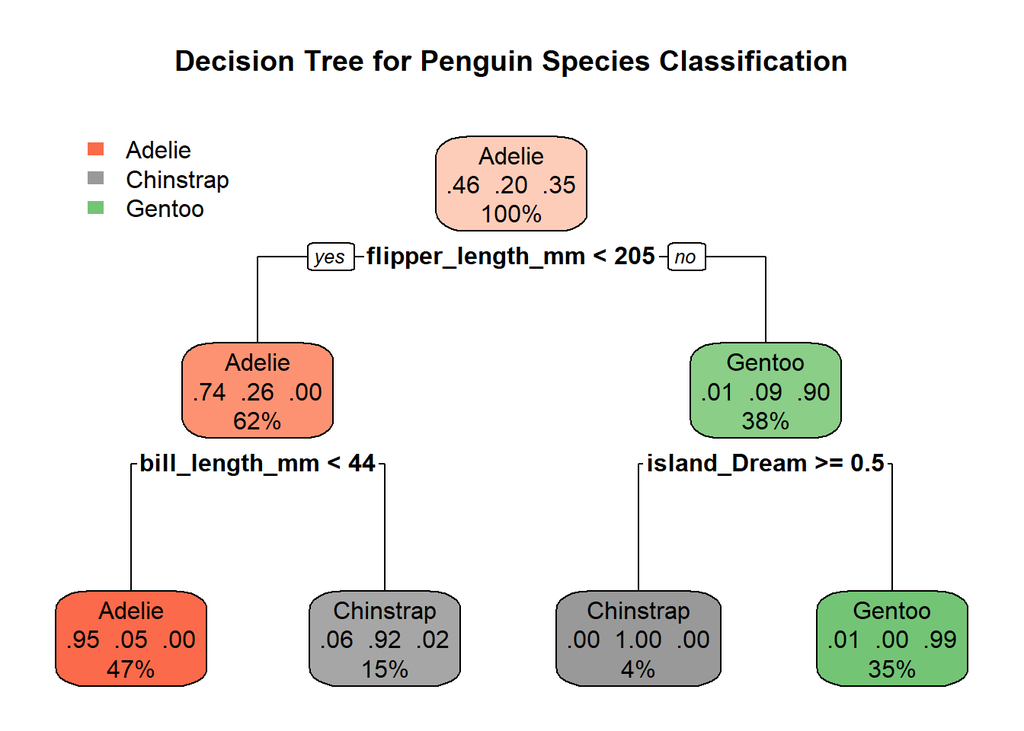

```r
library(rpart.plot)

dt_tree <- extract_fit_engine(dt_fit)

rpart.plot(
  dt_tree,
  type = 2,
  extra = 104,
  fallen.leaves = TRUE,
  main = "Decision Tree for Penguin Species Classification"
)
```

```r
dt_predictions <- predict(
  dt_fit,
  test_data
) |>
  bind_cols(test_data)

dt_metrics <- dt_predictions |>
  classification_metrics(
    truth = species,
    estimate = .pred_class
  )

dt_metrics
```

| .metric | .estimator | .estimate |
| --- | --- | --- |
| accuracy | multiclass | 0.9655172 |
| kap | multiclass | 0.9461745 |

```r
dt_conf_mat <- dt_predictions |>
  conf_mat(
    truth = species,
    estimate = .pred_class
  )

dt_conf_mat
```

```
##            Truth
## Prediction  Adelie Chinstrap Gentoo
##   Adelie        37         0      0
##   Chinstrap      3        17      0
##   Gentoo         0         0     30
```

#### Interpretation

The Decision Tree model provides a baseline classification result. Its performance metrics show how well a relatively simple and interpretable model can distinguish between penguin species using the selected predictor variables.

The confusion matrix can be used to identify which species are classified correctly and where misclassifications occur.

### Model 2

#### Model Description

A Random Forest classifier was selected as the second model. Random Forest extends the idea of a single decision tree by combining multiple trees into an ensemble model. This approach often improves predictive performance and reduces the risk of overfitting.

This model was selected because it is robust, works well with mixed predictor variables, and often provides strong performance in classification problems.

#### Implementation

```r
library(ranger)
rf_model <- rand_forest(
  trees = 500
) |>
  set_engine("ranger", importance = "impurity") |>
  set_mode("classification")

rf_workflow <- workflow() |>
  add_recipe(model_recipe) |>
  add_model(rf_model)

rf_fit <- fit(
  rf_workflow,
  data = train_data
)
```

Checking variable importance:

```r
library(vip)

vip(
  extract_fit_parsnip(rf_fit)$fit,
  num_features = 10
)
```

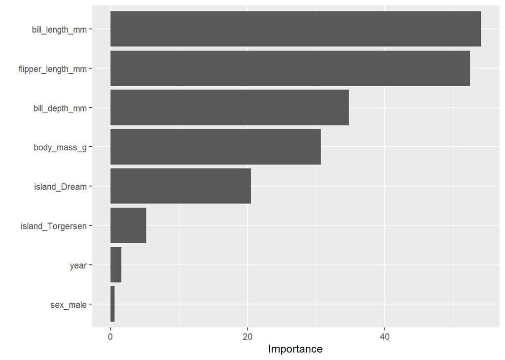

Variable importance indicates which predictors contributed most to the classification process. The plot helps identify variables that are most influential when distinguishing between penguin species.

With `ggplot` we can confirm:

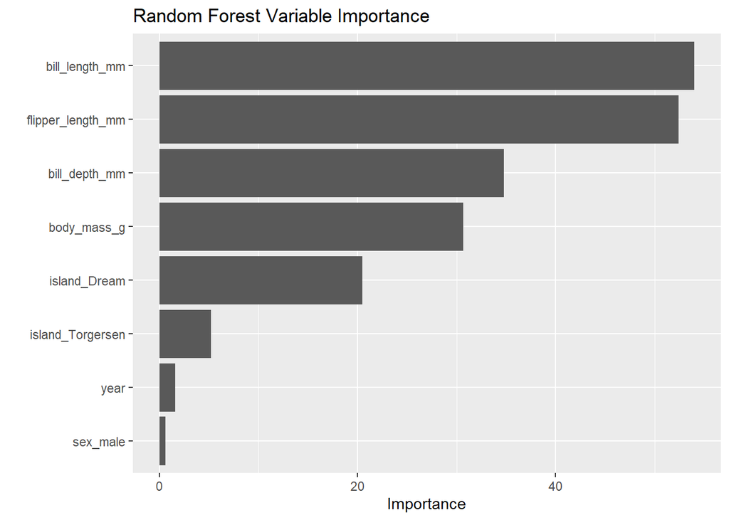

```r
rf_engine <- extract_fit_engine(rf_fit)

importance_df <- tibble(
  Variable = names(rf_engine$variable.importance),
  Importance = rf_engine$variable.importance
)

importance_df |>
  arrange(desc(Importance)) |>
  ggplot(aes(
    x = reorder(Variable, Importance),
    y = Importance
  )) +
  geom_col() +
  coord_flip() +
  labs(
    title = "Random Forest Variable Importance",
    x = "",
    y = "Importance"
  )
```

#### Results

```r
rf_predictions <- predict(
  rf_fit,
  test_data
) |>
  bind_cols(test_data)

rf_metrics <- rf_predictions |>
  classification_metrics(
    truth = species,
    estimate = .pred_class
  )

rf_metrics
```

| .metric | .estimator | .estimate |
| --- | --- | --- |
| accuracy | multiclass | 0.9770115 |
| kap | multiclass | 0.9639453 |

```r
rf_conf_mat <- rf_predictions |>
  conf_mat(
    truth = species,
    estimate = .pred_class
  )

rf_conf_mat
```

```
##            Truth
## Prediction  Adelie Chinstrap Gentoo
##   Adelie        38         0      0
##   Chinstrap      2        17      0
##   Gentoo         0         0     30
```

#### Interpretation

The Random Forest model was evaluated using the testing dataset. The obtained metrics indicate how effectively the model predicts penguin species based on the selected variables.

The results can be compared with the Decision Tree model to assess whether the ensemble approach improves predictive performance.

## Model Comparison

### Results

```r
model_comparison <- bind_rows(
  dt_metrics |> mutate(model = "Decision Tree"),
  rf_metrics |> mutate(model = "Random Forest")
) |>
  select(model, .metric, .estimate)

model_comparison
```

| model | .metric | .estimate |
| --- | --- | --- |
| Decision Tree | accuracy | 0.9655172 |
| Decision Tree | kap | 0.9461745 |
| Random Forest | accuracy | 0.9770115 |
| Random Forest | kap | 0.9639453 |

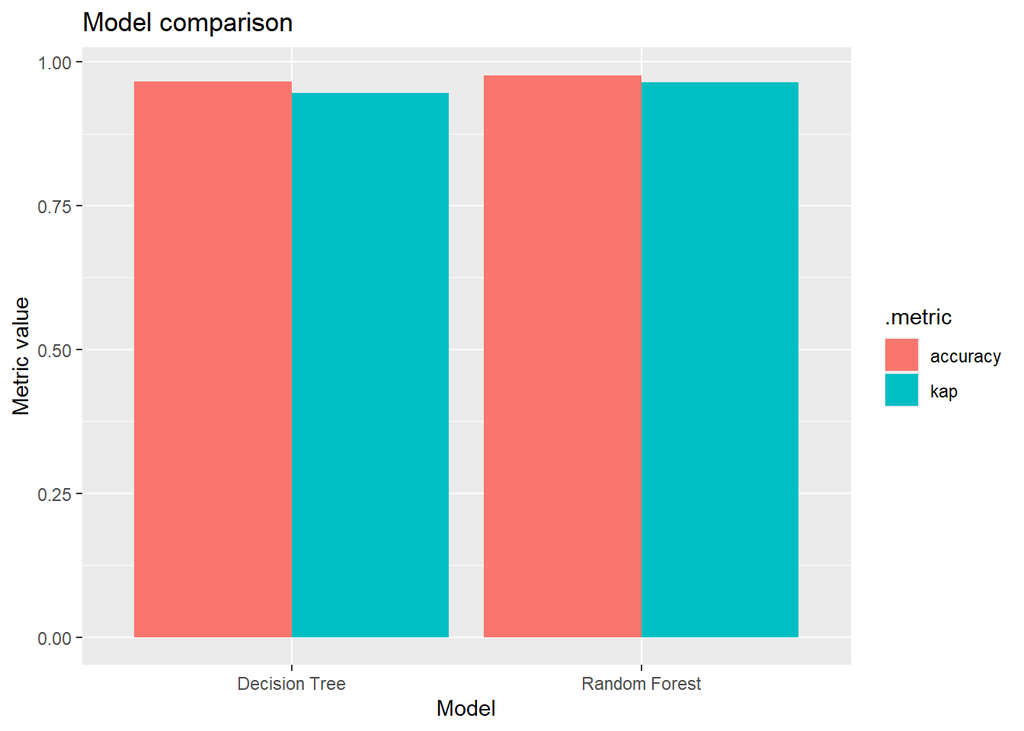

```r
model_comparison |>
  ggplot(aes(x = model, y = .estimate, fill = .metric)) +
  geom_col(position = "dodge") +
  labs(
    title = "Model comparison",
    x = "Model",
    y = "Metric value"
  )
```

### Interpretation

Both models were evaluated using the same testing dataset. The comparison allows assessment of whether the more complex Random Forest model provides better predictive performance than the simpler Decision Tree model.

The final model selection should consider both predictive performance and interpretability.

## Discussion

Two classification models were developed and evaluated: a Decision Tree and a Random Forest.

The Decision Tree model offers a high level of interpretability. The resulting tree structure can be visualized and easily understood, making it useful for explaining classification decisions. However, a single tree may be sensitive to variations in the training data and can be prone to overfitting.

The Random Forest model addresses some of these limitations by combining multiple decision trees into an ensemble. This approach generally improves predictive performance and robustness while reducing the impact of individual tree errors. The trade-off is reduced interpretability, as the model’s decision-making process becomes more complex.

Overall, both models demonstrate how machine learning techniques can be applied to classification problems. The comparison highlights the common trade-off between model interpretability and predictive performance.

## Limitations

Several limitations should be considered when interpreting the results.

First, the dataset required extensive cleaning due to missing values, inconsistent categorical labels, duplicate records, and implausible observations. The quality of the final models therefore depends on the assumptions made during the data preparation stage.

Second, the analysis was conducted using a single train-test split. Different random splits or cross-validation procedures could produce slightly different performance estimates.

Third, the project focused on a limited number of classification algorithms. Other approaches, such as k-Nearest Neighbours, Support Vector Machines, Gradient Boosting, or Neural Networks, may yield different results.

Finally, the dataset represents a specific collection of penguin observations. Consequently, conclusions should be interpreted within the context of this dataset and should not be generalized beyond the available data without additional validation.

# 7. Recommendations

# 8. Conclusions

The objective of this project was to develop and evaluate machine learning models capable of predicting penguin species based on morphological measurements and selected categorical attributes.

The project objectives were successfully achieved. Data quality issues, including missing values, inconsistent category labels, duplicate observations, and implausible values, were identified and addressed during the data preparation stage. This improved the overall consistency and usability of the dataset.

A meaningful exploratory data analysis was performed, providing insights into variable distributions, relationships between predictors, correlations, and potential outliers. These analyses supported subsequent data preparation and modelling decisions.

Two classification models, a Decision Tree and a Random Forest, were developed and evaluated using the prepared dataset. Model performance was assessed using objective evaluation metrics and confusion matrices, allowing a direct comparison of the two approaches.

The results demonstrate that machine learning techniques can effectively classify penguin species using the available predictor variables. While the Decision Tree offered greater interpretability, the Random Forest generally provided a more robust classification approach.

Overall, the success criteria defined at the beginning of the project were met:

- data quality issues were identified and addressed;
- meaningful exploratory analysis was performed;
- two classification models were developed;
- model performance was evaluated and compared;
- conclusions were supported by analytical evidence obtained throughout the CRISP-DM process.

The project illustrates the importance of systematic data preparation, exploratory analysis, and model evaluation when developing predictive solutions based on real-world data.

## Summary

This project followed the CRISP-DM methodology to develop and evaluate machine learning models for penguin species classification.

The analysis included data understanding, data cleaning, exploratory data analysis, feature preparation, model development, and model evaluation. Data quality issues were identified and addressed prior to modelling. Two classification algorithms, a Decision Tree and a Random Forest, were trained and evaluated using a dedicated testing dataset.

The results demonstrate the importance of systematic data preparation and model evaluation when building predictive solutions based on real-world data.

## Lessons Learned

Several important lessons emerged from this analysis.

First, data quality has a substantial impact on the modelling process. Missing values, inconsistent labels, duplicate observations, and implausible values required attention before reliable models could be developed.

Second, exploratory data analysis provided valuable insights into the structure of the dataset and helped guide data preparation decisions. Visualisation proved particularly useful for identifying unusual observations and understanding relationships between variables.

Third, different machine learning models offer different advantages. Simpler models such as Decision Trees provide interpretability, while ensemble methods such as Random Forests often deliver improved predictive performance.

Finally, model evaluation should extend beyond a single metric and include multiple perspectives, such as confusion matrices and comparative performance analysis.

## Future Work

Several extensions could be explored in future iterations of the project.

Additional classification algorithms, such as Support Vector Machines, k-Nearest Neighbours, Gradient Boosting, or Neural Networks, could be evaluated and compared with the models developed in this study.

More advanced feature engineering techniques could also be investigated to improve predictive performance. Cross-validation procedures could provide more robust estimates of model generalisation performance.

Finally, the analysis could be extended by incorporating additional biological or environmental variables, allowing more comprehensive modelling of penguin characteristics and species differentiation.

# References

# Appendix A (Optional)

# Appendix B -Explanatory Data Analysis Report

💡 Accessibility and Visual Design

The visualisations in this report were designed with readability and accessibility in mind. Colour palettes and formatting choices were selected to ensure that charts remain interpretable for a wide audience, including individuals with common forms of colour vision deficiency.

In addition to colour, visual distinctions such as point shapes, labels, and layout were used to improve clarity. These design choices help ensure that the presented insights remain understandable when viewed on different screens, projectors, or printed materials.

Effective data communication depends not only on accurate analysis but also on the ability to present results in a clear, accessible, and audience-friendly manner.

## Understanding Penguin Characteristics

The purpose of this report is not to build predictive models, but to communicate selected insights discovered in the penguin dataset. While exploratory analysis focuses on discovering patterns, explanatory analysis focuses on presenting findings in a clear and meaningful way for an audience.

The dataset contains measurements of penguins belonging to three species: Adelie, Chinstrap, and Gentoo. Several physical characteristics were recorded, including bill dimensions, flipper length, body mass, sex, and island of origin.

## Insight 1: Penguin Species Differ in Physical Characteristics

One of the most visible patterns in the dataset is the difference in body measurements between species.

These differences suggest that morphological measurements contain useful information for distinguishing between species.

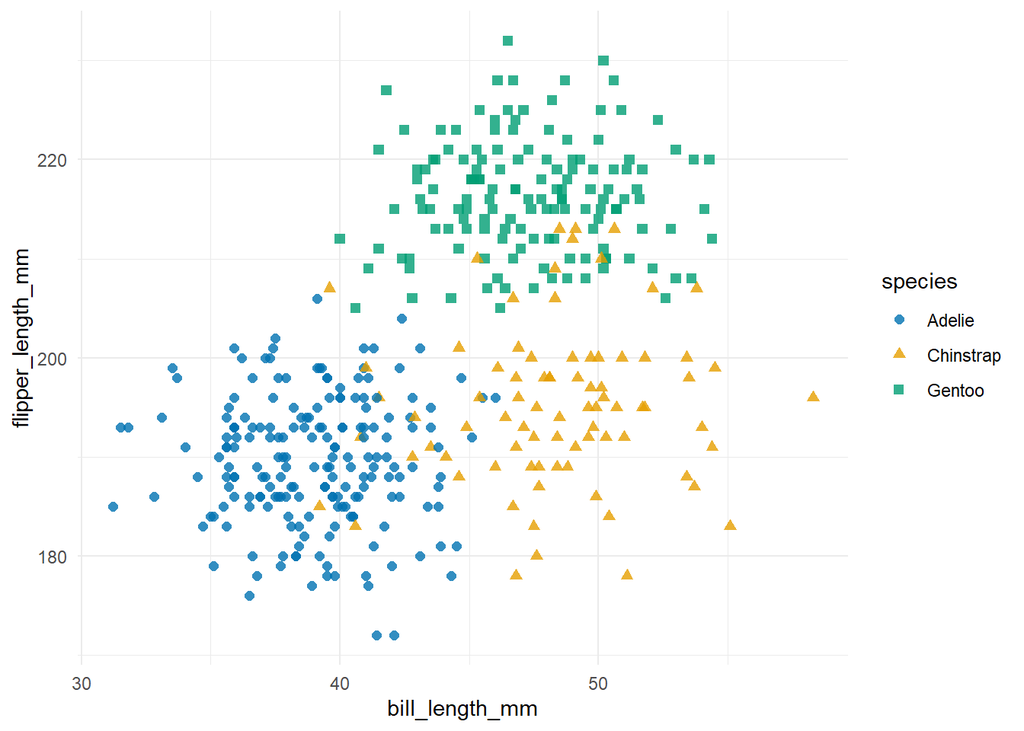

```r
ggplot(
  model_data,
  aes(
    x = bill_length_mm,
    y = flipper_length_mm,
    color = species,
    shape = species
  )
) +
  geom_point(
    size = 2,
    alpha = 0.8
  ) +
  scale_color_manual(
    values = c(
      "Adelie" = "#0072B2",
      "Chinstrap" = "#E69F00",
      "Gentoo" = "#009E73"
    )
  ) +
  theme_minimal()
```

The three penguin species occupy different regions of the feature space. This suggests that morphological measurements contain sufficient information to distinguish species and explains why classification models achieve good predictive performance.

## Insight 2: Species Distribution Across Islands

Species distribution was examined across islands to explore whether penguin species occur uniformly throughout the study area. Understanding geographic distribution patterns can provide additional biological context and help explain why location-related variables may be useful for classification

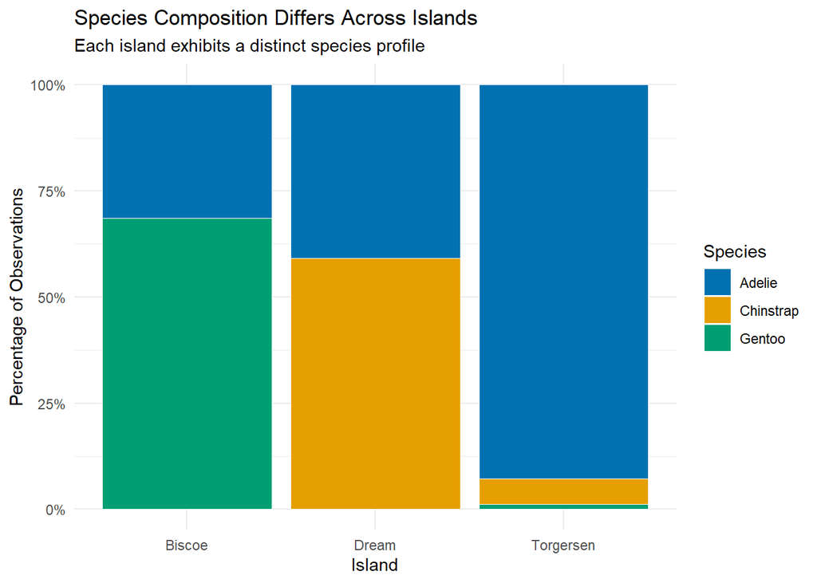

```r
ggplot(
  data,
  aes(
    x = island,
    fill = species
  )
) +
  geom_bar(
    position = "fill",
    color = "white",
    linewidth = 0.3
  ) +
  scale_fill_manual(
    values = c(
      "Adelie" = "#0072B2",
      "Chinstrap" = "#E69F00",
      "Gentoo" = "#009E73"
    )
  ) +
  scale_y_continuous(
    labels = scales::percent
  ) +
  theme_minimal() +
  labs(
    title = "Species Composition Differs Across Islands",
    subtitle = "Each island exhibits a distinct species profile",
    x = "Island",
    y = "Percentage of Observations",
    fill = "Species"
  )
```

One of the clearest patterns in the dataset is that penguin species are not evenly distributed across islands. Certain islands are associated with particular species, creating distinct geographic signatures. This observation demonstrates that location alone can provide valuable clues about species identity and helps explain why the island variable contributes to classification performance

## Insight 3: Data Quality Directly Affects Analysis Quality

The dataset contained several data quality issues, including:

- missing values,
- duplicate observations,
- inconsistent category labels,
- implausible numerical values.

These problems required cleaning before reliable analysis could be performed.

### Why It Matters

Poor data quality can distort visualisations, bias statistical summaries, and reduce model performance. Data preparation is therefore a critical step in any data mining project.

## Insight 4: Visualisation Reveals Patterns Hidden in Summary Statistics

Several relationships became visible only after visual exploration of the data.

Histograms revealed unusual observations and potential outliers. Scatterplots highlighted relationships between variables. Correlation analysis quantified some of these relationships, while boxplots illustrated differences between groups.

### Why It Matters

Numerical summaries alone rarely provide a complete understanding of a dataset. Visualisation remains one of the most effective tools for communicating analytical findings.

## Key Takeaways

The analysis demonstrates that: